# 02 – Hypothesis test: is TcyABC down-regulated in PASN?

Bio253 HS2026 · flagship exercise

**NoteHow to use this notebook**

Work through it **top to bottom** and write your answers into the boxes marked *Your answer*. Do not jump to the discussion before you have looked at the data yourself. There is no “right” answer pre-written here – the data decide.

```r
source("../R/setup.R")
```

## 1. Background

*S. aureus* takes up the amino acid L-cystine with the ABC transporter **TcyABC** (TcyA = substrate-binding protein, TcyB = permease, TcyC = ATPase; one operon, *tcyABC*).

In **Schwyter et al. 2025, *mSystems*** (doi:10.1128/msystems.00262-25) JE2 was evolved in medium containing cell-free, sterile-filtered spent medium of *Pseudomonas aeruginosa* PAO1 (“PA supernatant”, PASN). *S. aureus* never met living *P. aeruginosa*: it only sees the molecules *P. aeruginosa* secreted (e.g. HQNO, PQS, pyocyanin, siderophores, proteases) – and a medium that is partly depleted of nutrients. An evolved isolate carried a frameshift in *tcyA*; in its proteome TcyA was almost gone (log2FC −5.95 vs the ancestor) and TcyB was reduced (−2.86), probably a polar effect. A non-functional transporter gave partial protection against toxic compounds from *P. aeruginosa* (selenocystine, PQS) – presumably because they enter the cell through TcyABC.

This leads to an idea: *maybe the ancestor already down-regulates TcyABC when it is exposed to PASN – a fast, plastic version of what evolution did genetically?*

## 2. Formulate the hypothesis

Before you look at any number, write down:

- **H1 (your hypothesis):** in the ancestor (anc), TcyA/B/C abundance is ______ in SN than in TSB.
- **H0 (null hypothesis):** ______
- **Which contrast tests this, and which sign of `diff` would support H1?**

```r
explain_contrast("TSB_vs_SN_at_anc")
```

```
[1] "TSB_vs_SN_at_anc: diff = log2(TSB) - log2(SN), within anc. diff > 0 means HIGHER in TSB; diff < 0 means HIGHER in SN."
```

> *Your answer:* …

**TipCheck your formulation (open after you wrote yours)**

H0: mean log2 abundance in anc_SN = anc_TSB. H1 (one-sided): lower in anc_SN. With contrast `TSB_vs_SN_at_anc` (= TSB − SN), H1 predicts **diff > 0**. Also decide now how large a change you would call *biologically relevant* (e.g. |log2FC| > 1 = two-fold?). Deciding afterwards is cheating yourself.

## 3. Find the three proteins

Gene names are empty in this data set. We search by **locus tag** (JE2 genome CP020619.1).

```r
tcy <- find_protein(c("B7H15_13375", "B7H15_13370", "B7H15_13365")) |>
  select(protein_key, locus_tag, product, protein_id, staa8_uniprot, location) |>
  mutate(short_name = c(B7H15_13375 = "TcyA", B7H15_13370 = "TcyB",
                        B7H15_13365 = "TcyC")[locus_tag])
tcy
```

| protein_key | locus_tag | product | protein_id | staa8_uniprot | location | short_name |
| --- | --- | --- | --- | --- | --- | --- |
| lcl_CP020619.1_prot_ARG46974.1_2591 | B7H15_13365 | amino acid ABC transporter ATP-binding protein | ARG46974.1 | Q2FVL4 | complement(2534540..2535271) | TcyC |
| lcl_CP020619.1_prot_ARG46975.1_2592 | B7H15_13370 | amino acid ABC transporter permease | ARG46975.1 | Q2FVL3 | complement(2535268..2535987) | TcyB |
| lcl_CP020619.1_prot_ARG46976.1_2593 | B7H15_13375 | amino acid ABC transporter substrate-binding protein | ARG46976.1 | Q2FVL2 | complement(2535968..2536747) | TcyA |

**Question:** the products are just called “amino acid ABC transporter …”. How can you convince yourself these really are TcyA/B/C? (Hint: `staa8_uniprot` → look up the NCTC8325 ortholog on uniprot.org; check the location on the genome.)

There may be more than one way into the cell for cystine:

```r
find_protein("cystine") |> select(locus_tag, product, protein_id, staa8_uniprot)
```

| locus_tag | product | protein_id | staa8_uniprot |
| --- | --- | --- | --- |
| B7H15_02105 | L-cystine transporter | ARG44923.1 | Q2G0Z4 |

## 4. Look at the raw per-sample values first

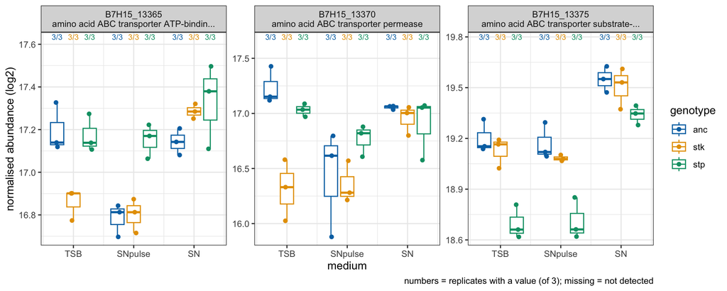

```r
abundances <- read_abundances("total")
plot_protein(tcy$locus_tag, abundances)
```

**Questions:** Is every replicate detected? Do the three replicates agree? Looking only at the anc TSB vs anc SN boxes – what do you expect the fold change to be?

> *Your answer:* …

## 5. What does the prolfquapp DEA say?

```r
dea <- read_dea("total")
tcy_dea <- dea |>
  filter(locus_tag %in% tcy$locus_tag,
         contrast %in% c("TSB_vs_SN_at_anc", "TSB_vs_SN_at_stk", "TSB_vs_SN_at_stp",
                         "TSB_vs_SNpulse_at_anc")) |>
  left_join(select(tcy, locus_tag, short_name), by = "locus_tag") |>
  transmute(short_name, contrast, diff = round(diff, 2),
            fold_change = round(2^diff, 2), conf.low = round(conf.low, 2),
            conf.high = round(conf.high, 2), FDR = signif(FDR, 2), estimate_type) |>
  arrange(short_name, contrast)
tcy_dea
```

| short_name | contrast | diff | fold_change | conf.low | conf.high | FDR | estimate_type |
| --- | --- | --- | --- | --- | --- | --- | --- |
| TcyA | TSB_vs_SN_at_anc | -0.35 | 0.78 | -0.51 | -0.19 | 4.1e-04 | observed |
| TcyA | TSB_vs_SN_at_stk | -0.38 | 0.77 | -0.53 | -0.22 | 1.6e-04 | observed |
| TcyA | TSB_vs_SN_at_stp | -0.65 | 0.64 | -0.80 | -0.49 | 1.0e-07 | observed |
| TcyA | TSB_vs_SNpulse_at_anc | 0.03 | 1.02 | -0.13 | 0.18 | 9.1e-01 | observed |
| TcyB | TSB_vs_SN_at_anc | 0.18 | 1.13 | -0.17 | 0.53 | 4.1e-01 | observed |
| TcyB | TSB_vs_SN_at_stk | -0.62 | 0.65 | -1.00 | -0.24 | 6.3e-03 | observed |
| TcyB | TSB_vs_SN_at_stp | 0.13 | 1.09 | -0.24 | 0.49 | 6.0e-01 | observed |
| TcyB | TSB_vs_SNpulse_at_anc | 0.78 | 1.72 | 0.41 | 1.15 | 7.4e-03 | observed |
| TcyC | TSB_vs_SN_at_anc | 0.05 | 1.04 | -0.11 | 0.22 | 6.4e-01 | observed |
| TcyC | TSB_vs_SN_at_stk | -0.42 | 0.75 | -0.59 | -0.26 | 9.0e-05 | observed |
| TcyC | TSB_vs_SN_at_stp | -0.15 | 0.90 | -0.32 | 0.01 | 1.1e-01 | observed |
| TcyC | TSB_vs_SNpulse_at_anc | 0.41 | 1.33 | 0.24 | 0.57 | 1.9e-03 | observed |

Translate the sign into words for TcyA in the ancestor:

```r
tcyA_anc <- filter(tcy_dea, short_name == "TcyA", contrast == "TSB_vs_SN_at_anc")
sprintf("TcyA, anc: diff = %.2f -> TcyA is %s in TSB than in SN (factor %.2f)",
        tcyA_anc$diff, if_else(tcyA_anc$diff > 0, "HIGHER", "LOWER"),
        2^abs(tcyA_anc$diff))
```

```
[1] "TcyA, anc: diff = -0.35 -> TcyA is LOWER in TSB than in SN (factor 1.27)"
```

> *Your answer:* does this support H1 or not?

## 6. Do your own test

Never trust a single tool. Re-do the comparison anc_TSB vs anc_SN yourself.

### 6a. A t-test on 3 vs 3

```r
my_t_test <- function(key, data = abundances) {
  x <- filter(data, protein_key == key, group %in% c("anc_TSB", "anc_SN"))
  tsb <- x$normalized_abundance[x$group == "anc_TSB"]
  sn  <- x$normalized_abundance[x$group == "anc_SN"]
  welch <- t.test(tsb, sn)                    # unequal variances
  student <- t.test(tsb, sn, var.equal = TRUE)
  tibble(protein_key = key,
         mean_TSB = mean(tsb), mean_SN = mean(sn),
         diff_TSB_minus_SN = mean(tsb) - mean(sn),
         p_welch = welch$p.value, p_student = student$p.value)
}
own <- purrr::map(tcy$protein_key, my_t_test) |> bind_rows() |>
  left_join(select(tcy, protein_key, short_name), by = "protein_key") |>
  relocate(short_name)
own |> mutate(across(where(is.numeric), \(v) signif(v, 3)))
```

| short_name | protein_key | mean_TSB | mean_SN | diff_TSB_minus_SN | p_welch | p_student |
| --- | --- | --- | --- | --- | --- | --- |
| TcyC | lcl_CP020619.1_prot_ARG46974.1_2591 | 17.2 | 17.1 | 0.0522 | 0.53700 | 0.52700 |
| TcyB | lcl_CP020619.1_prot_ARG46975.1_2592 | 17.2 | 17.1 | 0.1780 | 0.21000 | 0.14500 |
| TcyA | lcl_CP020619.1_prot_ARG46976.1_2593 | 19.2 | 19.5 | -0.3480 | 0.00943 | 0.00829 |

**Question:** the t-test p-values are not adjusted for testing ~2300 proteins. Why is that a problem? Why is that *less* of a problem here, where you test a hypothesis you formulated *before* looking at the data?

### 6b. limma – borrowing information across proteins

With only 3 replicates the variance per protein is very uncertain. `limma` shrinks each protein’s variance towards the typical variance of all proteins (“moderated t-test”). prolfquapp does something similar.

```r
library(limma)
samples <- read_samples()
mat <- abundances |>
  select(protein_key, sample, normalized_abundance) |>
  pivot_wider(names_from = sample, values_from = normalized_abundance)
m <- as.matrix(mat[, samples$sample])         # columns in the order of the sample sheet
rownames(m) <- mat$protein_key

group  <- samples$group
design <- model.matrix(~ 0 + group)
colnames(design) <- levels(group)
fit <- lmFit(m, design)                         # proteins with NAs use their observed values
contr <- makeContrasts(TSB_vs_SN_at_anc = anc_TSB - anc_SN, levels = design)
fit2 <- eBayes(contrasts.fit(fit, contr))
limma_res <- topTable(fit2, number = Inf, sort.by = "none") |>
  as_tibble(rownames = "protein_key") |>
  mutate(FDR_limma = p.adjust(P.Value, "BH"))

comparison <- tcy |>
  select(short_name, protein_key) |>
  left_join(select(own, protein_key, diff_ttest = diff_TSB_minus_SN, p_welch), by = "protein_key") |>
  left_join(select(limma_res, protein_key, diff_limma = logFC, p_limma = P.Value, FDR_limma),
            by = "protein_key") |>
  left_join(dea |> filter(contrast == "TSB_vs_SN_at_anc") |>
              select(protein_key, diff_prolfqua = diff, p_prolfqua = p.value, FDR_prolfqua = FDR),
            by = "protein_key") |>
  select(-protein_key)
comparison |> mutate(across(where(is.numeric), \(v) signif(v, 3)))
```

| short_name | diff_ttest | p_welch | diff_limma | p_limma | FDR_limma | diff_prolfqua | p_prolfqua | FDR_prolfqua |
| --- | --- | --- | --- | --- | --- | --- | --- | --- |
| TcyC | 0.0522 | 0.53700 | 0.0522 | 0.549000 | 0.64200 | 0.0524 | 0.514000 | 0.635000 |
| TcyB | 0.1780 | 0.21000 | 0.1780 | 0.351000 | 0.44800 | 0.1810 | 0.300000 | 0.407000 |
| TcyA | -0.3480 | 0.00943 | -0.3480 | 0.000361 | 0.00101 | -0.3490 | 0.000132 | 0.000413 |

**Questions:** Do the three methods agree on the *direction*? On the *size*? On “significant or not”? Where do they differ, and why?

## 7. Effect size vs significance

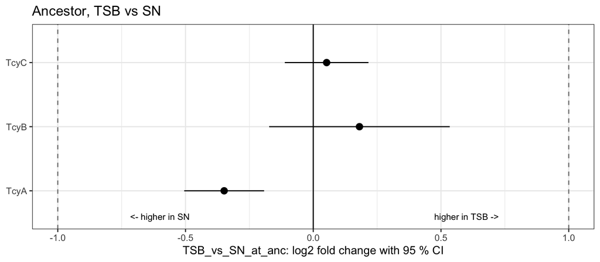

```r
dea |>
  filter(locus_tag %in% tcy$locus_tag, contrast == "TSB_vs_SN_at_anc") |>
  left_join(select(tcy, locus_tag, short_name), by = "locus_tag") |>
  ggplot(aes(diff, short_name)) +
  geom_vline(xintercept = 0) +
  geom_vline(xintercept = c(-1, 1), linetype = "dashed", colour = "grey50") +
  geom_pointrange(aes(xmin = conf.low, xmax = conf.high)) +
  annotate("text", x = 0.6, y = 0.6, label = "higher in TSB ->", size = 3) +
  annotate("text", x = -0.6, y = 0.6, label = "<- higher in SN", size = 3) +
  labs(x = "TSB_vs_SN_at_anc: log2 fold change with 95 % CI", y = NULL,
       title = "Ancestor, TSB vs SN")
```

For comparison: in the evolved *tcyA* frameshift mutant, TcyA dropped by log2FC −5.95 (≈ 60-fold). Put your fold changes on the same scale.

**Questions:** A change can be *statistically significant* and still *tiny*. Which is the case here? What would you need to call TcyABC “down-regulated”?

## 8. Your conclusion

> *Your answer:* Is H0 rejected? In which direction? Is the effect biologically relevant? How confident are you, and what are the caveats?

## 9. Discussion prompts

Discuss in your group (and write the outcome in your lab notebook):

1. **Plastic vs genetic response.** In *mSystems* the strong TcyA loss was a *genetic* effect (evolved frameshift vs ancestor). Here you look at the *plastic* effect of the medium in a non-evolved strain. Should those two agree? Why might a cell *not* down-regulate a transporter plastically even if losing it is adaptive?
2. **Operons and polar effects.** *tcyA, tcyB, tcyC* are co-transcribed. Do the three proteins move together here? Why did the frameshift in *tcyA* also reduce TcyB?
3. **Alternative routes.** Look at the L-cystine symporter (TcyP-like, `B7H15_02105`). What happens to it in SN? Could the cell compensate? `plot_protein("B7H15_02105")`
4. **Abundance ≠ activity.** A transporter can be present but closed, or inhibited by competition with other substrates. What experiment would measure *uptake* instead of protein amount?
5. **Nutrient depletion vs toxin defence.** SN = 70 % TSB + 30 % *spent*, cell-free *P. aeruginosa* medium. Spent medium is nutrient-poor – cystine/cysteine may be partly used up. Bacteria often *up*-regulate uptake systems when a nutrient becomes scarce. So a change in a transporter may reflect **nutrient availability** rather than **defence against secreted toxins**. Which experiment would separate the two (hint: TSB diluted with saline only; spent medium with cystine added back)?
6. **Short pulse.** Would you expect a change in protein amount after 15 min (SNpulse)?

## 10. Secondary question: do the kinase/phosphatase mutants change Tcy levels?

```r
dea |>
  filter(locus_tag %in% tcy$locus_tag,
         contrast %in% c("stk_vs_anc_at_TSB", "stp_vs_anc_at_TSB",
                         "stk_vs_anc_at_SN", "stp_vs_anc_at_SN")) |>
  left_join(select(tcy, locus_tag, short_name), by = "locus_tag") |>
  transmute(short_name, contrast, diff = round(diff, 2), FDR = signif(FDR, 2), estimate_type) |>
  arrange(short_name, contrast)
```

| short_name | contrast | diff | FDR | estimate_type |
| --- | --- | --- | --- | --- |
| TcyA | stk_vs_anc_at_SN | -0.05 | 7.5e-01 | observed |
| TcyA | stk_vs_anc_at_TSB | -0.07 | 5.3e-01 | observed |
| TcyA | stp_vs_anc_at_SN | -0.21 | 3.6e-02 | observed |
| TcyA | stp_vs_anc_at_TSB | -0.51 | 1.6e-05 | observed |
| TcyB | stk_vs_anc_at_SN | -0.10 | 7.8e-01 | observed |
| TcyB | stk_vs_anc_at_TSB | -0.90 | 5.5e-04 | observed |
| TcyB | stp_vs_anc_at_SN | -0.15 | 5.7e-01 | observed |
| TcyB | stp_vs_anc_at_TSB | -0.20 | 3.7e-01 | observed |
| TcyC | stk_vs_anc_at_SN | 0.15 | 2.1e-01 | observed |
| TcyC | stk_vs_anc_at_TSB | -0.33 | 3.4e-03 | observed |
| TcyC | stp_vs_anc_at_SN | 0.18 | 8.3e-02 | observed |
| TcyC | stp_vs_anc_at_TSB | -0.02 | 8.8e-01 | observed |

```r
explain_contrast("stp_vs_anc_at_TSB")
```

```
[1] "stp_vs_anc_at_TSB: diff = log2(stp) - log2(anc), within TSB. diff > 0 means HIGHER in stp; diff < 0 means HIGHER in anc."
```

**Questions:** Is any Tcy protein different in the mutants? Before you interpret it as “Stp1 controls TcyA”: check notebook 03 – is the `stp` strain really a clean *stp1* mutant?